# IODS course project

# Chapter 3: Logistic regression

```r
date()
```

```
## [1] "Sun Dec 12 11:44:03 2021"
```

## 3.1 The data

Source: [https://archive.ics.uci.edu/ml/datasets/Student+Performance#]

In the data frame ‘alc’ there are 370 observations of 51 variables.

I chose student’s sex, the quality of their family relationships, and parents educational background to observe in relation to the use of alcohol.

```r
alc <- read.csv2("https://github.com/rsund/IODS-project/raw/master/data/alc.csv", sep = "," , header=TRUE)
str(alc)
```

```
## 'data.frame':    370 obs. of  51 variables:
##  $ school    : chr  "GP" "GP" "GP" "GP" ...
##  $ sex       : chr  "F" "F" "F" "F" ...
##  $ age       : int  15 15 15 15 15 15 15 15 15 15 ...
##  $ address   : chr  "R" "R" "R" "R" ...
##  $ famsize   : chr  "GT3" "GT3" "GT3" "GT3" ...
##  $ Pstatus   : chr  "T" "T" "T" "T" ...
##  $ Medu      : int  1 1 2 2 3 3 3 2 3 3 ...
##  $ Fedu      : int  1 1 2 4 3 4 4 2 1 3 ...
##  $ Mjob      : chr  "at_home" "other" "at_home" "services" ...
##  $ Fjob      : chr  "other" "other" "other" "health" ...
##  $ reason    : chr  "home" "reputation" "reputation" "course" ...
##  $ guardian  : chr  "mother" "mother" "mother" "mother" ...
##  $ traveltime: int  2 1 1 1 2 1 2 2 2 1 ...
##  $ studytime : int  4 2 1 3 3 3 3 2 4 4 ...
```

[output cut: 37 more lines]

```r
colnames(alc)
```

```
##  [1] "school"     "sex"        "age"        "address"    "famsize"
##  [6] "Pstatus"    "Medu"       "Fedu"       "Mjob"       "Fjob"
## [11] "reason"     "guardian"   "traveltime" "studytime"  "schoolsup"
## [16] "famsup"     "activities" "nursery"    "higher"     "internet"
## [21] "romantic"   "famrel"     "freetime"   "goout"      "Dalc"
## [26] "Walc"       "health"     "n"          "id.p"       "id.m"
## [31] "failures"   "paid"       "absences"   "G1"         "G2"
## [36] "G3"         "failures.p" "paid.p"     "absences.p" "G1.p"
## [41] "G2.p"       "G3.p"       "failures.m" "paid.m"     "absences.m"
## [46] "G1.m"       "G2.m"       "G3.m"       "alc_use"    "high_use"
## [51] "cid"
```

```r
#Mutated famrel, medu & fedu to factors
alc2 <- alc %>%
  mutate(
    famrel= factor(famrel, levels = c(1,2,3,4,5), labels = c("very bad","bad","neutral","good","very good")),
         Medu = factor(Medu, levels = c(0,1,2,3,4), labels = c("none","primary","5-9th","sec ed", "high ed")),
         Fedu = factor(Fedu, levels = c(0,1,2,3,4), labels = c("none","primary","5-9th","sec ed", "high ed")))

str(alc2)
```

```
## 'data.frame':    370 obs. of  51 variables:
##  $ school    : chr  "GP" "GP" "GP" "GP" ...
##  $ sex       : chr  "F" "F" "F" "F" ...
##  $ age       : int  15 15 15 15 15 15 15 15 15 15 ...
##  $ address   : chr  "R" "R" "R" "R" ...
##  $ famsize   : chr  "GT3" "GT3" "GT3" "GT3" ...
##  $ Pstatus   : chr  "T" "T" "T" "T" ...
##  $ Medu      : Factor w/ 5 levels "none","primary",..: 2 2 3 3 4 4 4 3 4 4 ...
##  $ Fedu      : Factor w/ 5 levels "none","primary",..: 2 2 3 5 4 5 5 3 2 4 ...
##  $ Mjob      : chr  "at_home" "other" "at_home" "services" ...
##  $ Fjob      : chr  "other" "other" "other" "health" ...
##  $ reason    : chr  "home" "reputation" "reputation" "course" ...
##  $ guardian  : chr  "mother" "mother" "mother" "mother" ...
##  $ traveltime: int  2 1 1 1 2 1 2 2 2 1 ...
##  $ studytime : int  4 2 1 3 3 3 3 2 4 4 ...
```

[output cut: 37 more lines]

## 3.2 The hypotheses

I chose student’s sex, the quality of their family relationships, and parents educational background to observe in relation to the use of alcohol.

My hypotheses are: I. The sex male predicts high alcohol use II. The quality of family relationships predicts high alcohol use III. Mothers educational level predicts high alcohol use IV. Fathers educational level predicts high alcohol use

```r
gather(alc2) %>% glimpse
```

```
## Rows: 18,870
## Columns: 2
## $ key   <chr> "school", "school", "school", "school", "school", "school", "sch~
## $ value <chr> "GP", "GP", "GP", "GP", "GP", "GP", "GP", "GP", "GP", "GP", "GP"~
```

[figure not shown]

```r
gather(alc2) %>% ggplot(aes(value)) + facet_wrap("key", scales = "free") + geom_bar()
```

## 3.3 The variables

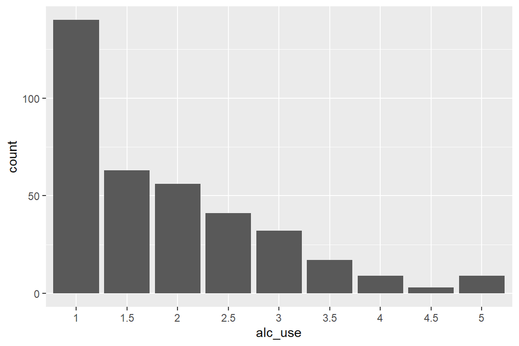

```r
#Alcohol use & high_use
ggplot(data = alc2, aes(x = alc_use))+ geom_bar()
```

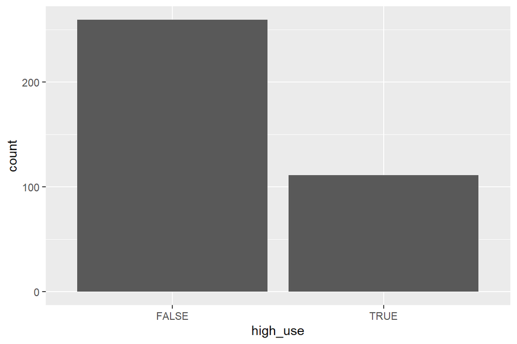

```r
ggplot(data = alc2, aes(x = high_use))+ geom_bar()
```

```r
# The counts of different groups
alc2 %>% group_by(high_use) %>% summarise(count = n())
```

```
## # A tibble: 2 x 2
##   high_use count
##   <lgl>    <int>
## 1 FALSE      259
## 2 TRUE       111
```

```r
alc2 %>% group_by(high_use, sex) %>% summarise(count = n())
```

```
## # A tibble: 4 x 3
## # Groups:   high_use [2]
##   high_use sex   count
##   <lgl>    <chr> <int>
## 1 FALSE    F       154
## 2 FALSE    M       105
## 3 TRUE     F        41
## 4 TRUE     M        70
```

```r
# The aggregate data and the data frame
alc_agg2 <- alc %>%
  group_by(high_use)%>%
  summarise(
            famrel_mean = round(mean(famrel), digits = 2),
            famrel_sd = round(sd(famrel), digits = 2),
            medu_mean = round(mean(Medu), digits = 2),
            medu_sd = round(sd(Medu), digits = 2),
            fedu_mean = round(mean(Fedu), digits = 2),
            fedu_sd = round(sd(Fedu), digits = 2),
             n=n())
alc_agg2
```

```
## # A tibble: 2 x 8
##   high_use famrel_mean famrel_sd medu_mean medu_sd fedu_mean fedu_sd     n
##   <lgl>          <dbl>     <dbl>     <dbl>   <dbl>     <dbl>   <dbl> <int>
## 1 FALSE           4.01      0.89      2.8     1.07      2.55    1.08   259
## 2 TRUE            3.77      0.93      2.79    1.13      2.57    1.11   111
```

### Sex

```r
# The frequencies & and the relative frequencies and the bar plots of high-use/low-use in the group sex

table(alc2$high_use, alc2$sex)
```

```
##
##           F   M
##   FALSE 154 105
##   TRUE   41  70
```

```r
round(prop.table(table(alc2$high_use, alc2$sex),2)*100)
```

```
##
##          F  M
##   FALSE 79 60
##   TRUE  21 40
```

```r
alc2 %>% group_by(high_use, sex) %>% summarise(count = n())%>%ungroup()
```

```
## # A tibble: 4 x 3
##   high_use sex   count
##   <lgl>    <chr> <int>
## 1 FALSE    F       154
## 2 FALSE    M       105
## 3 TRUE     F        41
## 4 TRUE     M        70
```

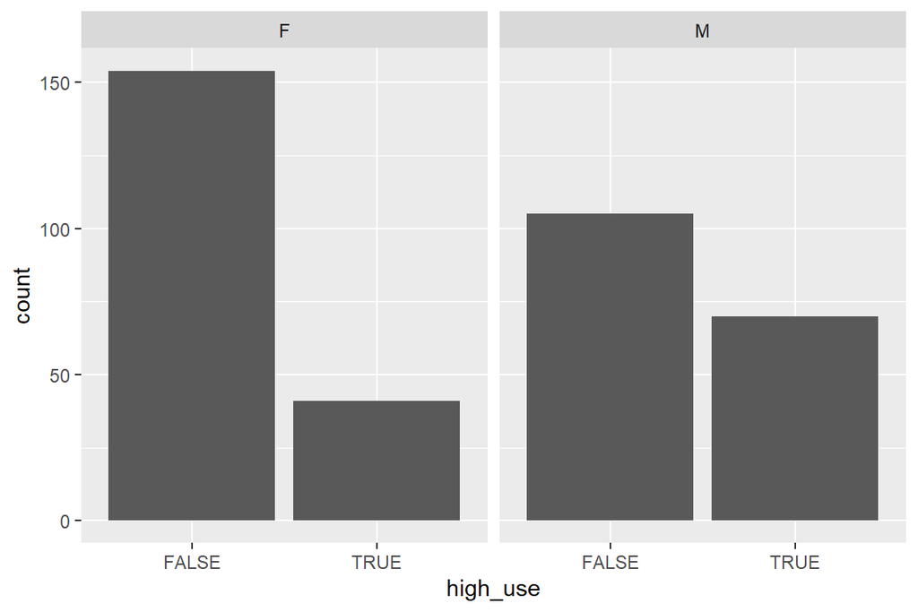

```r
ggplot(data = alc2, aes(x = high_use))+ geom_bar() + facet_wrap(~sex)
```

### Family relationships

```r
# The frequencies & percentages of high-use by the different family relation points
table(alc2$high_use, alc2$famrel)
```

```
##
##         very bad bad neutral good very good
##   FALSE        6   9      39  128        77
##   TRUE         2   9      25   52        23
```

```r
prop.table(table(alc2$high_use, alc2$famrel))*100
```

```
##
##           very bad        bad    neutral       good  very good
##   FALSE  1.6216216  2.4324324 10.5405405 34.5945946 20.8108108
##   TRUE   0.5405405  2.4324324  6.7567568 14.0540541  6.2162162
```

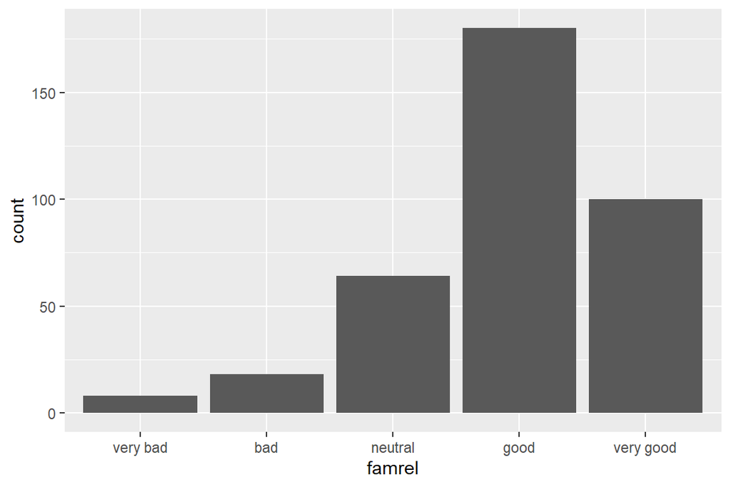

```r
# Plots
ggplot(data = alc2, aes(x = famrel))+ geom_bar()
```

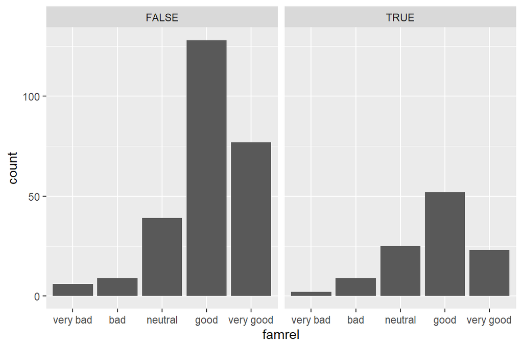

```r
ggplot(data = alc2, aes(x = famrel))+ geom_bar() + facet_wrap(~high_use)
```

### Mothers education

```r
# The frequencies & percentages of high-use by the different mothers educational background points
table(alc2$high_use, alc2$Medu)
```

```
##
##         none primary 5-9th sec ed high ed
##   FALSE    1      31    78     57      92
##   TRUE     2      18    18     36      37
```

```r
prop.table(table(alc2$high_use, alc2$Medu))*100
```

```
##
##               none    primary      5-9th     sec ed    high ed
##   FALSE  0.2702703  8.3783784 21.0810811 15.4054054 24.8648649
##   TRUE   0.5405405  4.8648649  4.8648649  9.7297297 10.0000000
```

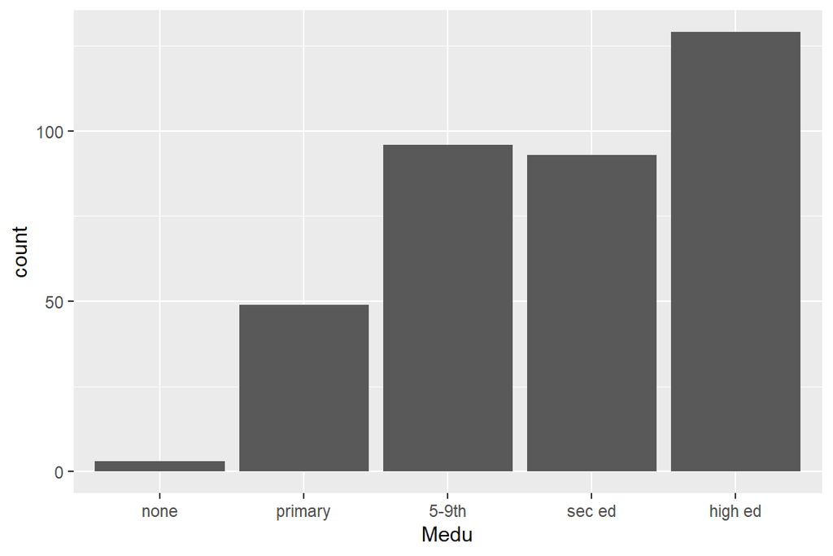

```r
# Plots
ggplot(data = alc2, aes(x = Medu))+ geom_bar()
```

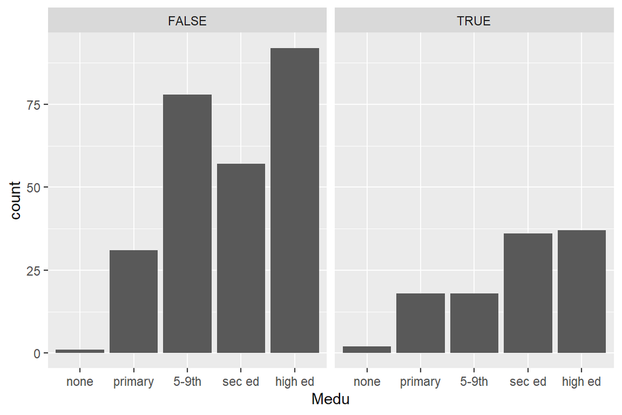

```r
ggplot(data = alc2, aes(x = Medu))+ geom_bar() + facet_wrap(~high_use)
```

### Fathers education

```r
# The frequencies & percentages of high-use by the different fathers educational background points
table(alc2$high_use, alc2$Fedu) #xtabs(~ high_use + Fedu, data=alc) optional way
```

```
##
##         none primary 5-9th sec ed high ed
##   FALSE    2      49    75     70      63
##   TRUE     0      24    30     27      30
```

```r
prop.table(table(alc2$high_use, alc2$Fedu))*100
```

```
##
##               none    primary      5-9th     sec ed    high ed
##   FALSE  0.5405405 13.2432432 20.2702703 18.9189189 17.0270270
##   TRUE   0.0000000  6.4864865  8.1081081  7.2972973  8.1081081
```

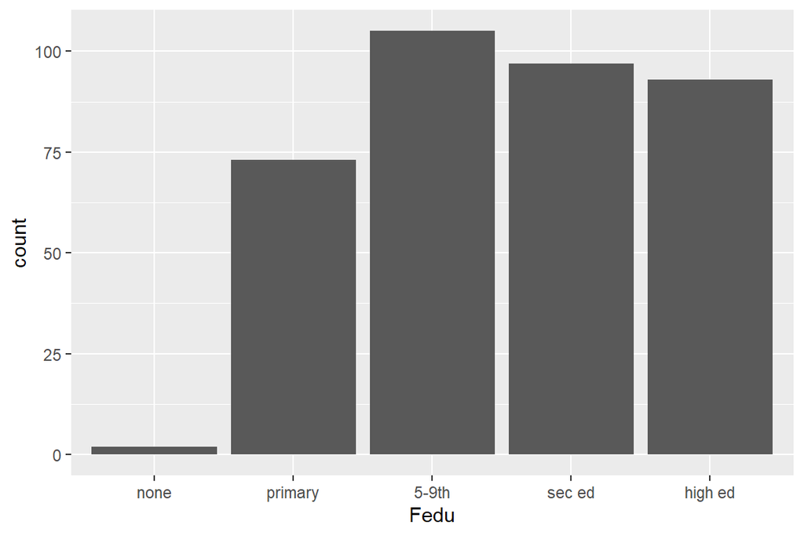

```r
#Plots
ggplot(data = alc2, aes(x = Fedu))+ geom_bar()
```

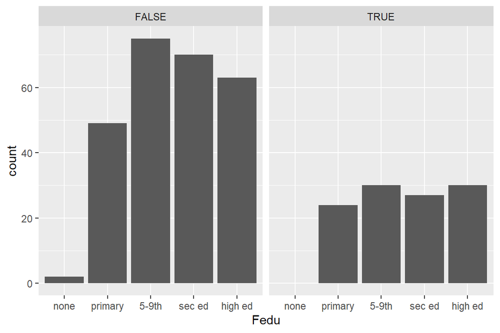

```r
ggplot(data = alc2, aes(x = Fedu))+ geom_bar() + facet_wrap(~high_use)
```

### Summary of the data and the chosen variables

The frequency of observations in the high-use category is lower than in the low-use (high use n=111, low-use n=259). The sexes are almost equally distributed, (f=195, m=175).

The frequency of high usage is higher with the male group (males: high-use n= 70, low-use n=105), than females (females: high-use n= 41, low-use n=154).

## 3.4 The model

In the first model m = (high_use ~ sex + famrel + Medu + Fedu) only the sex was statistically significant. (Here, the sex male = 1, as the sex female = 0)

In the second fitted model m2 (high_use ~ sex, data = alc2) the coefficients show, that the estimate for male high alcohol being use is 0.9179 (p<.000), that indicates the odds of a males high alcohol consumption over the odds of a females high alcohol consumption.

High-use log(odds) male = -1.3234 + 0.9179 * 1 = -0.4055 High-use log(odds) female = -1.3234 + 0.9179 * 0 = -1.3234

The odds ratio (OR) is 2,5 (CI[1,59 - 3,98]), that indicates there is a positive association with the sex (male) and high alcohol consumption.

“the exponents of the coefficients of a logistic regression model can be interpret as odds ratios between a unit change (vs no change) in the corresponding explanatory variable.”

My hypotheses were:

I. The sex male predicts high alcohol use II. The quality of family relationships predicts high alcohol use III. Mothers educational level predicts high alcohol use IV. Fathers educational level predicts high alcohol use

According to the logistic regression model the sex of the subjects has a statistical relationship with high/low alcohol consumption: the odds of the male of high alcohol consumption are bigger than in females. The first hypothesis was confirmed, the others can be refuted.

```r
m <- glm(high_use ~ sex + famrel + Medu + Fedu, data = alc2, family = "binomial")
summary(m)
```

```
##
## Call:
## glm(formula = high_use ~ sex + famrel + Medu + Fedu, family = "binomial",
##     data = alc2)
##
## Deviance Residuals:
##     Min       1Q   Median       3Q      Max
## -1.5222  -0.8386  -0.6155   1.1266   2.2264
##
## Coefficients:
##                 Estimate Std. Error z value Pr(>|z|)
## (Intercept)     -14.7820   624.1411  -0.024    0.981
## sexM              1.0620     0.2478   4.285 1.83e-05 ***
## famrelbad         1.0664     0.9760   1.093    0.275
## famrelneutral     0.7208     0.8863   0.813    0.416
## famrelgood        0.2204     0.8598   0.256    0.798
## famrelvery good  -0.2642     0.8792  -0.300    0.764
## Meduprimary      -1.0962     1.2850  -0.853    0.394
## Medu5-9th        -2.0024     1.2732  -1.573    0.116
## Medusec ed       -0.8768     1.2785  -0.686    0.493
## Meduhigh ed      -1.5378     1.2905  -1.192    0.233
## Feduprimary      14.6700   624.1392   0.024    0.981
## Fedu5-9th        14.5305   624.1392   0.023    0.981
## Fedusec ed       14.3553   624.1392   0.023    0.982
## Feduhigh ed      14.6577   624.1392   0.023    0.981
## ---
## Signif. codes:  0 '***' 0.001 '**' 0.01 '*' 0.05 '.' 0.1 ' ' 1
##
## (Dispersion parameter for binomial family taken to be 1)
##
##     Null deviance: 452.04  on 369  degrees of freedom
## Residual deviance: 409.69  on 356  degrees of freedom
## AIC: 437.69
##
## Number of Fisher Scoring iterations: 13
```

```r
m2 <- glm(high_use ~ sex, data = alc2, family = "binomial")
summary(m2)
```

```
##
## Call:
## glm(formula = high_use ~ sex, family = "binomial", data = alc2)
##
## Deviance Residuals:
##     Min       1Q   Median       3Q      Max
## -1.0108  -1.0108  -0.6871   1.3537   1.7660
##
## Coefficients:
##             Estimate Std. Error z value Pr(>|z|)
## (Intercept)  -1.3234     0.1757  -7.530 5.06e-14 ***
## sexM          0.9179     0.2339   3.925 8.67e-05 ***
## ---
## Signif. codes:  0 '***' 0.001 '**' 0.01 '*' 0.05 '.' 0.1 ' ' 1
##
## (Dispersion parameter for binomial family taken to be 1)
##
##     Null deviance: 452.04  on 369  degrees of freedom
## Residual deviance: 436.13  on 368  degrees of freedom
## AIC: 440.13
##
## Number of Fisher Scoring iterations: 4
```

```r
# odds ratios (OR) and confidence intervals (CI)
OR <- coef(m2) %>% exp
OR # = 2,5 (sexM)
```

```
## (Intercept)        sexM
##   0.2662338   2.5040650
```

```r
CI <- confint(m2) %>% exp
CI # 1,59 - 3,98
```

```
##                 2.5 %    97.5 %
## (Intercept) 0.1863238 0.3717646
## sexM        1.5902950 3.9838892
```

```r
cbind(OR, CI)
```

```
##                    OR     2.5 %    97.5 %
## (Intercept) 0.2662338 0.1863238 0.3717646
## sexM        2.5040650 1.5902950 3.9838892
```

## The predictive power of the model

The average number of wrong predictions in the cross validation is 0.31.

```r
# Predict() the probability of high_use
probabilities <- predict(m2, type = "response")

# Add the predicted probabilities to 'alc'
alc2 <- mutate(alc2, probability = probabilities)

# The probabilities to make a prediction of high_use
alc2 <- mutate(alc2, prediction = probability > 0.5)

# The target variable versus the predictions
table(high_use = alc2$high_use, prediction = alc2$prediction)
```

```
##         prediction
## high_use FALSE
##    FALSE   259
##    TRUE    111
```

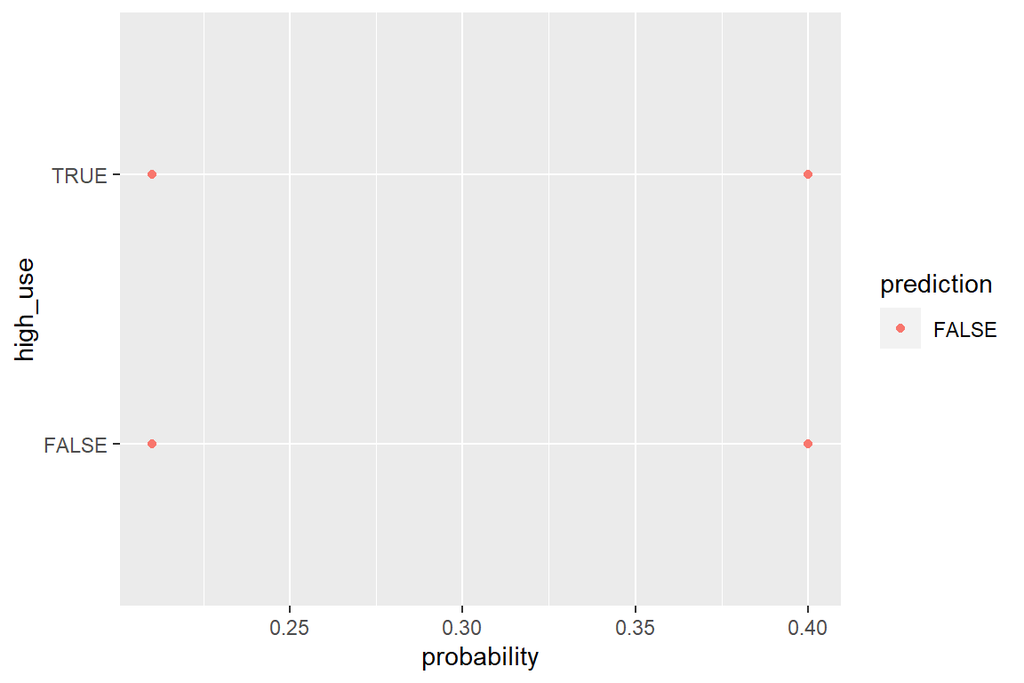

```r
# A plot of 'high_use' versus 'probability' in 'alc', define the geom as points and draw the plot
ggplot(alc2, aes(x = probability, y = high_use, col = prediction))+ geom_point()
```

```r
# tabulate the target variable versus the predictions
table(high_use = alc2$high_use, prediction = alc2$prediction) %>% prop.table %>% addmargins
```

```
##         prediction
## high_use FALSE Sum
##    FALSE   0.7 0.7
##    TRUE    0.3 0.3
##    Sum     1.0 1.0
```

```r
# define a loss function (average prediction error)
loss_func <- function(class, prob) {
  n_wrong <- abs(class - prob) > 0.5
  mean(n_wrong)
}

# call loss_func to compute the average number of wrong predictions in the (training) data
loss_func(class = alc2$high_use, prob = alc2$probability)
```

```
## [1] 0.3
```

```r
# K-fold cross-validation
library(boot)
cv <- cv.glm(data = alc2, cost = loss_func, glmfit = m, K = 10)

# average number of wrong predictions in the cross validation
cv$delta[1]
```

```
## [1] 0.3108108
```

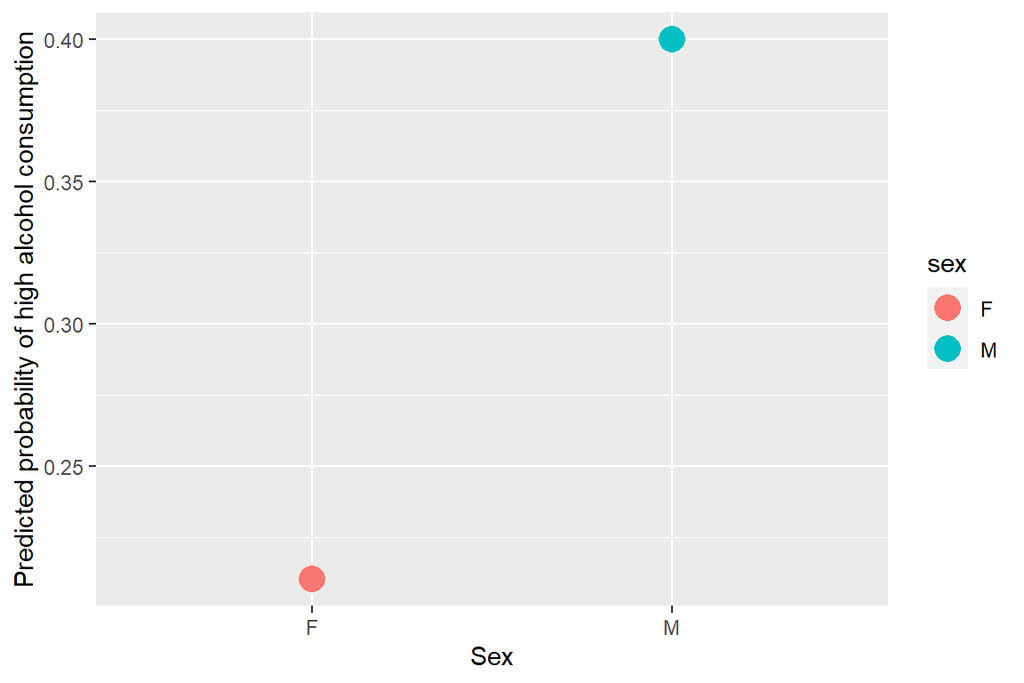

```r
######
#I found an applied this demo script from here:  https://github.com/StatQuest/logistic_regression_demo/blob/master/logistic_regression_demo.R

predicted.data <- data.frame(
  probability.of.high.a = m2$fitted.values,
  sex=alc2$sex)

ggplot(data=predicted.data, aes(x=sex, y=probability.of.high.a)) +
  geom_point(aes(color=sex), size=5) +
  xlab("Sex") +
  ylab("Predicted probability of high alcohol consumption")
```

```r
######
```

```r
# access the MASS package
library(MASS)
```

```r
library(tidyverse)
library(ggplot2)
library(corrplot)
getwd()
```

```
## [1] "C:/LocalData/krraiha/Opiskelu HY/Jatko-opinnot/IODS-project"
```

# Chapter 4: Clustering and classification

```r
date()
```

```
## [1] "Sun Dec 12 11:44:14 2021"
```

## 4.1 The data

The data *Boston* consists of 506 observations of 14 variables. Details of the variables are shown here: [https://stat.ethz.ch/R-manual/R-devel/library/MASS/html/Boston.html].

```r
# load the data
data("Boston")

str(Boston)
```

```
## 'data.frame':    506 obs. of  14 variables:
##  $ crim   : num  0.00632 0.02731 0.02729 0.03237 0.06905 ...
##  $ zn     : num  18 0 0 0 0 0 12.5 12.5 12.5 12.5 ...
##  $ indus  : num  2.31 7.07 7.07 2.18 2.18 2.18 7.87 7.87 7.87 7.87 ...
##  $ chas   : int  0 0 0 0 0 0 0 0 0 0 ...
##  $ nox    : num  0.538 0.469 0.469 0.458 0.458 0.458 0.524 0.524 0.524 0.524 ...
##  $ rm     : num  6.58 6.42 7.18 7 7.15 ...
##  $ age    : num  65.2 78.9 61.1 45.8 54.2 58.7 66.6 96.1 100 85.9 ...
##  $ dis    : num  4.09 4.97 4.97 6.06 6.06 ...
##  $ rad    : int  1 2 2 3 3 3 5 5 5 5 ...
##  $ tax    : num  296 242 242 222 222 222 311 311 311 311 ...
##  $ ptratio: num  15.3 17.8 17.8 18.7 18.7 18.7 15.2 15.2 15.2 15.2 ...
##  $ black  : num  397 397 393 395 397 ...
##  $ lstat  : num  4.98 9.14 4.03 2.94 5.33 ...
##  $ medv   : num  24 21.6 34.7 33.4 36.2 28.7 22.9 27.1 16.5 18.9 ...
```

```r
summary(Boston)
```

```
##       crim                zn             indus            chas
##  Min.   : 0.00632   Min.   :  0.00   Min.   : 0.46   Min.   :0.00000
##  1st Qu.: 0.08205   1st Qu.:  0.00   1st Qu.: 5.19   1st Qu.:0.00000
##  Median : 0.25651   Median :  0.00   Median : 9.69   Median :0.00000
##  Mean   : 3.61352   Mean   : 11.36   Mean   :11.14   Mean   :0.06917
##  3rd Qu.: 3.67708   3rd Qu.: 12.50   3rd Qu.:18.10   3rd Qu.:0.00000
##  Max.   :88.97620   Max.   :100.00   Max.   :27.74   Max.   :1.00000
##       nox               rm             age              dis
##  Min.   :0.3850   Min.   :3.561   Min.   :  2.90   Min.   : 1.130
##  1st Qu.:0.4490   1st Qu.:5.886   1st Qu.: 45.02   1st Qu.: 2.100
##  Median :0.5380   Median :6.208   Median : 77.50   Median : 3.207
##  Mean   :0.5547   Mean   :6.285   Mean   : 68.57   Mean   : 3.795
##  3rd Qu.:0.6240   3rd Qu.:6.623   3rd Qu.: 94.08   3rd Qu.: 5.188
##  Max.   :0.8710   Max.   :8.780   Max.   :100.00   Max.   :12.127
##       rad              tax           ptratio          black
##  Min.   : 1.000   Min.   :187.0   Min.   :12.60   Min.   :  0.32
##  1st Qu.: 4.000   1st Qu.:279.0   1st Qu.:17.40   1st Qu.:375.38
##  Median : 5.000   Median :330.0   Median :19.05   Median :391.44
##  Mean   : 9.549   Mean   :408.2   Mean   :18.46   Mean   :356.67
##  3rd Qu.:24.000   3rd Qu.:666.0   3rd Qu.:20.20   3rd Qu.:396.23
##  Max.   :24.000   Max.   :711.0   Max.   :22.00   Max.   :396.90
##      lstat            medv
##  Min.   : 1.73   Min.   : 5.00
##  1st Qu.: 6.95   1st Qu.:17.02
##  Median :11.36   Median :21.20
##  Mean   :12.65   Mean   :22.53
##  3rd Qu.:16.95   3rd Qu.:25.00
##  Max.   :37.97   Max.   :50.00
```

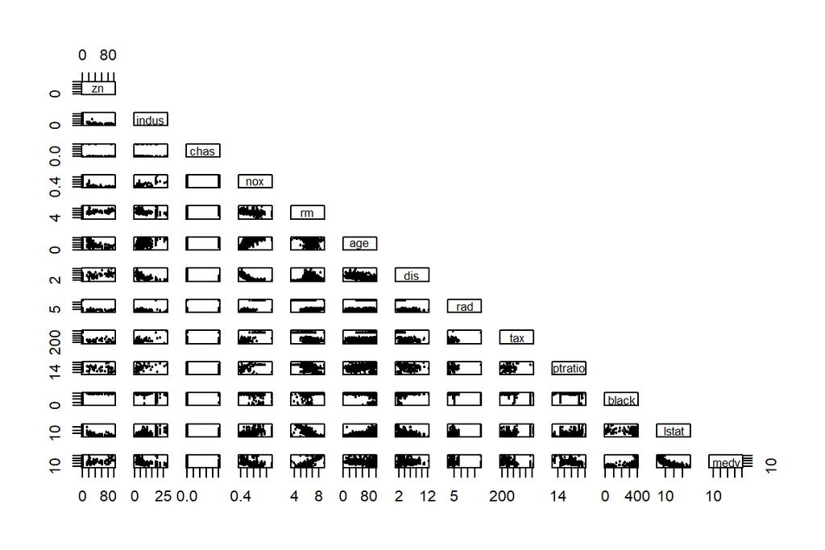

```r
# plot matrix of the variables
pairs(Boston[,c(2:14)], pch = 20, cex=0.4, upper.panel=NULL)
```

```r
# rounded correlation matrix
cor_matrix<-cor(Boston) %>% round(digits = 2)

# print the correlation matrix
cor_matrix
```

```
##          crim    zn indus  chas   nox    rm   age   dis   rad   tax ptratio
## crim     1.00 -0.20  0.41 -0.06  0.42 -0.22  0.35 -0.38  0.63  0.58    0.29
## zn      -0.20  1.00 -0.53 -0.04 -0.52  0.31 -0.57  0.66 -0.31 -0.31   -0.39
## indus    0.41 -0.53  1.00  0.06  0.76 -0.39  0.64 -0.71  0.60  0.72    0.38
## chas    -0.06 -0.04  0.06  1.00  0.09  0.09  0.09 -0.10 -0.01 -0.04   -0.12
## nox      0.42 -0.52  0.76  0.09  1.00 -0.30  0.73 -0.77  0.61  0.67    0.19
## rm      -0.22  0.31 -0.39  0.09 -0.30  1.00 -0.24  0.21 -0.21 -0.29   -0.36
## age      0.35 -0.57  0.64  0.09  0.73 -0.24  1.00 -0.75  0.46  0.51    0.26
## dis     -0.38  0.66 -0.71 -0.10 -0.77  0.21 -0.75  1.00 -0.49 -0.53   -0.23
## rad      0.63 -0.31  0.60 -0.01  0.61 -0.21  0.46 -0.49  1.00  0.91    0.46
## tax      0.58 -0.31  0.72 -0.04  0.67 -0.29  0.51 -0.53  0.91  1.00    0.46
## ptratio  0.29 -0.39  0.38 -0.12  0.19 -0.36  0.26 -0.23  0.46  0.46    1.00
## black   -0.39  0.18 -0.36  0.05 -0.38  0.13 -0.27  0.29 -0.44 -0.44   -0.18
## lstat    0.46 -0.41  0.60 -0.05  0.59 -0.61  0.60 -0.50  0.49  0.54    0.37
## medv    -0.39  0.36 -0.48  0.18 -0.43  0.70 -0.38  0.25 -0.38 -0.47   -0.51
##         black lstat  medv
## crim    -0.39  0.46 -0.39
## zn       0.18 -0.41  0.36
## indus   -0.36  0.60 -0.48
## chas     0.05 -0.05  0.18
## nox     -0.38  0.59 -0.43
## rm       0.13 -0.61  0.70
## age     -0.27  0.60 -0.38
## dis      0.29 -0.50  0.25
## rad     -0.44  0.49 -0.38
## tax     -0.44  0.54 -0.47
## ptratio -0.18  0.37 -0.51
## black    1.00 -0.37  0.33
## lstat   -0.37  1.00 -0.74
## medv     0.33 -0.74  1.00
```

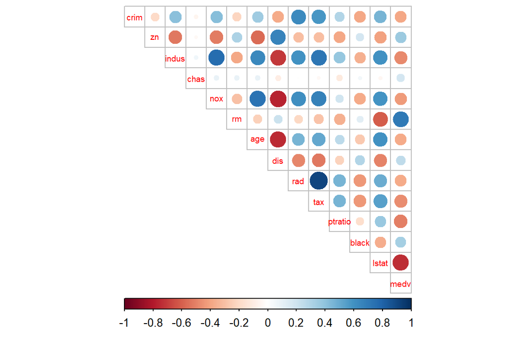

```r
# visualisation of the correlation matrix
corrplot(cor_matrix, method="circle", type="upper", cl.pos="b", tl.pos="d", tl.cex = 0.6)
```

## 4.2 Data standardization

Linear discriminant analysis produces results based on the assumptions that variables are normally distributed, the normal distributions for each class share the same covariance matrix, and the variables are continuous.Because of the assumptions, the data might need scaling before fitting the model.

Below is the dataset standardized with the summaries. The function ´scale´ is generic function whose default method centers and/or scales the columns of a numeric matrix. In the scaling the column means are subtracted from the corresponding columns and the the difference is divided with standard deviation. The scaling makes the means of the variables in dataset boston 0.

```r
boston_scaled <- scale(Boston) # center and standardize variables
summary(boston_scaled)# summaries of the scaled variables
```

```
##       crim                 zn               indus              chas
##  Min.   :-0.419367   Min.   :-0.48724   Min.   :-1.5563   Min.   :-0.2723
##  1st Qu.:-0.410563   1st Qu.:-0.48724   1st Qu.:-0.8668   1st Qu.:-0.2723
##  Median :-0.390280   Median :-0.48724   Median :-0.2109   Median :-0.2723
##  Mean   : 0.000000   Mean   : 0.00000   Mean   : 0.0000   Mean   : 0.0000
##  3rd Qu.: 0.007389   3rd Qu.: 0.04872   3rd Qu.: 1.0150   3rd Qu.:-0.2723
##  Max.   : 9.924110   Max.   : 3.80047   Max.   : 2.4202   Max.   : 3.6648
##       nox                rm               age               dis
##  Min.   :-1.4644   Min.   :-3.8764   Min.   :-2.3331   Min.   :-1.2658
##  1st Qu.:-0.9121   1st Qu.:-0.5681   1st Qu.:-0.8366   1st Qu.:-0.8049
##  Median :-0.1441   Median :-0.1084   Median : 0.3171   Median :-0.2790
##  Mean   : 0.0000   Mean   : 0.0000   Mean   : 0.0000   Mean   : 0.0000
##  3rd Qu.: 0.5981   3rd Qu.: 0.4823   3rd Qu.: 0.9059   3rd Qu.: 0.6617
##  Max.   : 2.7296   Max.   : 3.5515   Max.   : 1.1164   Max.   : 3.9566
##       rad               tax             ptratio            black
##  Min.   :-0.9819   Min.   :-1.3127   Min.   :-2.7047   Min.   :-3.9033
##  1st Qu.:-0.6373   1st Qu.:-0.7668   1st Qu.:-0.4876   1st Qu.: 0.2049
##  Median :-0.5225   Median :-0.4642   Median : 0.2746   Median : 0.3808
##  Mean   : 0.0000   Mean   : 0.0000   Mean   : 0.0000   Mean   : 0.0000
##  3rd Qu.: 1.6596   3rd Qu.: 1.5294   3rd Qu.: 0.8058   3rd Qu.: 0.4332
##  Max.   : 1.6596   Max.   : 1.7964   Max.   : 1.6372   Max.   : 0.4406
##      lstat              medv
##  Min.   :-1.5296   Min.   :-1.9063
##  1st Qu.:-0.7986   1st Qu.:-0.5989
##  Median :-0.1811   Median :-0.1449
##  Mean   : 0.0000   Mean   : 0.0000
##  3rd Qu.: 0.6024   3rd Qu.: 0.2683
##  Max.   : 3.5453   Max.   : 2.9865
```

```r
class(boston_scaled)# class of the boston_scaled object
```

```
## [1] "matrix" "array"
```

```r
boston_scaled <- as.data.frame(boston_scaled) # change the object to data frame
```

## 4.3 Creating the testdata

Here a categorical variable of the crime rate is created, with quantiles and the old crime rate variable dropped. The dataset is then divided to train (80% of the data) and test sets.

```r
summary(boston_scaled$crim) #summary of the scaled crime rate
```

```
##      Min.   1st Qu.    Median      Mean   3rd Qu.      Max.
## -0.419367 -0.410563 -0.390280  0.000000  0.007389  9.924110
```

```r
bins <- quantile(boston_scaled$crim) #a quantile vector crim
bins
```

```
##           0%          25%          50%          75%         100%
## -0.419366929 -0.410563278 -0.390280295  0.007389247  9.924109610
```

```r
crime <- cut(boston_scaled$crim, breaks = bins, include.lowest = TRUE, labels = c("low", "med_low", "med_high", "high")) # a categorical variable 'crime'
table(crime) # table of the new factor crime
```

```
## crime
##      low  med_low med_high     high
##      127      126      126      127
```

```r
boston_scaled <- dplyr::select(boston_scaled, -crim)# original crim removed from the dataset
boston_scaled <- data.frame(boston_scaled, crime)# adding the new categorical value to scaled data

n <- nrow(boston_scaled) # number of rows in the Boston dataset
ind <- sample(n,  size = n * 0.8) # choosing a random 80% of the rows
train <- boston_scaled[ind,] # the train set
test <- boston_scaled[-ind,] # the test set
```

## 4.4 LDA

https://tuomonieminen.github.io/Helsinki-Open-Data-Science/#/40

Here a linear discriminant analysis (LDA) is fitted using the categorical crime rate as the target variable and all the other variables as predictors.

Based on the trained model LDA calculates the probabilities for the new observation for belonging in each of the classes. The observation is classified to the class of the highest probability

```r
lda.fit <- lda(crime ~ ., data = train) # the LDA model
lda.fit
```

```
## Call:
## lda(crime ~ ., data = train)
##
## Prior probabilities of groups:
##       low   med_low  med_high      high
## 0.2574257 0.2475248 0.2500000 0.2450495
##
## Group means:
##                  zn      indus        chas        nox         rm        age
## low       0.9658412 -0.9018724 -0.08304540 -0.8841955  0.4447934 -0.9039475
## med_low  -0.1214982 -0.2448968 -0.07547406 -0.5490795 -0.1733297 -0.3765304
## med_high -0.3581843  0.1807997  0.19544522  0.3877253  0.1291061  0.4290960
## high     -0.4872402  1.0171737 -0.03371693  1.0666237 -0.4034814  0.8051655
##                 dis        rad        tax      ptratio       black       lstat
## low       0.9014201 -0.6859201 -0.7479900 -0.446695793  0.37789963 -0.78780382
## med_low   0.3676775 -0.5569384 -0.4426156 -0.009022674  0.31565377 -0.10125431
## med_high -0.3803482 -0.4417506 -0.3335019 -0.348527706  0.08135892 -0.02775662
## high     -0.8710055  1.6375616  1.5136504  0.780117019 -0.77644063  0.88671527
##                 medv
## low       0.53840959
## med_low  -0.05836689
## med_high  0.20689526
## high     -0.68439179
##
## Coefficients of linear discriminants:
##                 LD1          LD2         LD3
## zn       0.08511525  0.648410424 -1.01261297
## indus    0.07288079 -0.170256592  0.18098456
## chas    -0.07789872 -0.053263257  0.08094124
## nox      0.34132980 -0.835823643 -1.12692775
## rm      -0.12457028 -0.057554348 -0.09272671
## age      0.14516910 -0.361380035 -0.29594295
## dis     -0.07184869 -0.262589980  0.21688892
## rad      3.42072245  0.953416400 -0.41084273
## tax     -0.03140000 -0.005918647  0.88860756
## ptratio  0.09719130  0.029001467 -0.21017656
## black   -0.10007413  0.030548941  0.14083134
## lstat    0.26155385 -0.190458774  0.42212744
## medv     0.21986697 -0.345084981 -0.19974944
##
## Proportion of trace:
##    LD1    LD2    LD3
## 0.9489 0.0371 0.0140
```

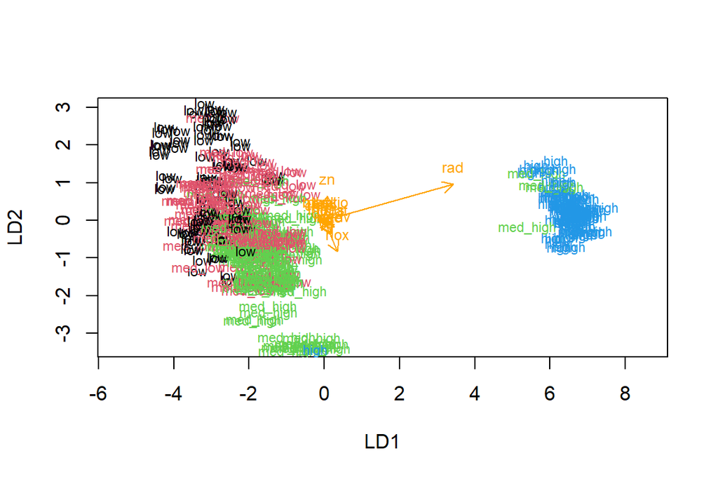

```r
# LDA biplot arrows
lda.arrows <- function(x, myscale = 1, arrow_heads = 0.1, color = "orange", tex = 0.75, choices = c(1,2)){
  heads <- coef(x)
  arrows(x0 = 0, y0 = 0,
         x1 = myscale * heads[,choices[1]],
         y1 = myscale * heads[,choices[2]], col=color, length = arrow_heads)
  text(myscale * heads[,choices], labels = row.names(heads),
       cex = tex, col=color, pos=3)
}

classes <- as.numeric(train$crime) # target classes as numeric

# plot of the LDA results
plot(lda.fit, dimen = 2, col = classes, pch = classes)
lda.arrows(lda.fit, myscale = 1)
```

### Predicting the classes

```r
correct_classes <- test$crime # saving the correct classes from test data

test <- dplyr::select(test, -crime) # removing the crime variable from test data

lda.pred <- predict(lda.fit, newdata = test)# predicting the classes with test data

result <- table(correct = correct_classes, predicted = lda.pred$class) #cross tab of the results
result
```

```
##           predicted
## correct    low med_low med_high high
##   low       13       8        2    0
##   med_low    5      17        4    0
##   med_high   0       2       21    2
##   high       0       0        0   28
```

```r
diag(prop.table(result, 1)) #probability table
```

```
##       low   med_low  med_high      high
## 0.5652174 0.6538462 0.8400000 1.0000000
```

```r
sum(diag(prop.table(result))) # ennustetarkkuus
```

```
## [1] 0.7745098
```

## 4.5 K-means

K-means is an unsupervised method, that assigns observations to groups or clusters based on similarity of the objects. K-means needs the number of clusters as an argument.

In this exercise the the Boston dataset is first reloaded, and standardized.

The distances between the observations are calculated: the observation belongs to the category whose center is closest to it.

The optimal number of clusters is investigated. One way to determine the number of clusters is to look at how the total of within cluster sum of squares (WCSS) behaves when the number of cluster changes. When plotting the number of clusters and the total WCSS, the optimal number of clusters is when the total WCSS drops radically.

if I interpreted the graphs correctly, there are no clear clusters and the optimal number is 2.

```r
data("Boston")

boston_scaled <- scale(Boston) # center and standardize variables
class(boston_scaled) # class of the boston_scaled object
```

```
## [1] "matrix" "array"
```

```r
boston_scaled <- as.data.frame(boston_scaled)# changes the object to data frame

dist_eu <- dist(boston_scaled) # euclidean distance matrix
summary(dist_eu) # summary of the distances
```

```
##    Min. 1st Qu.  Median    Mean 3rd Qu.    Max.
##  0.1343  3.4625  4.8241  4.9111  6.1863 14.3970
```

```r
dist_man <- dist(boston_scaled, method = 'manhattan') # manhattan distance matrix
summary(dist_man)# summary of the distances
```

```
##    Min. 1st Qu.  Median    Mean 3rd Qu.    Max.
##  0.2662  8.4832 12.6090 13.5488 17.7568 48.8618
```

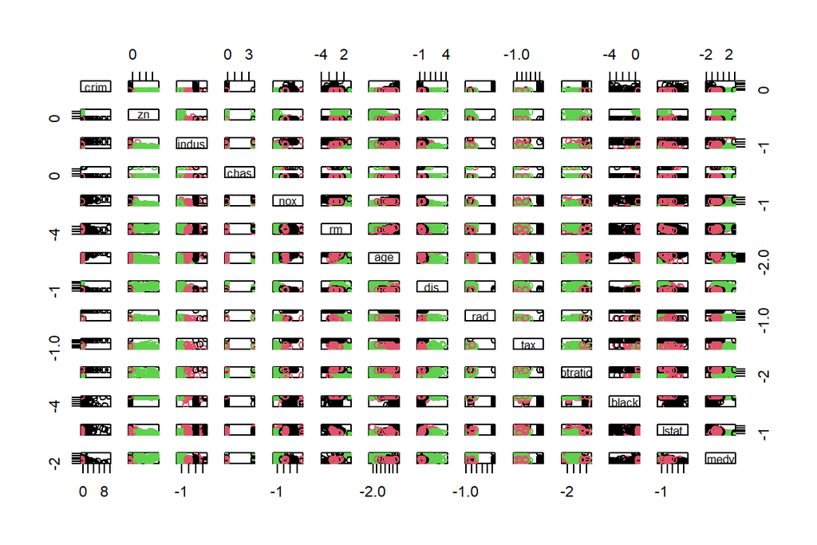

```r
set.seed(123) # K-means might produce different results every time, because it randomly assigns the initial cluster centers. The function set.seed deals with that.

##### here with 3 centers

km <-kmeans(boston_scaled, centers = 3) # k-means clustering

pairs(boston_scaled, col = km$cluster) # plot of the Boston dataset with clusters
```

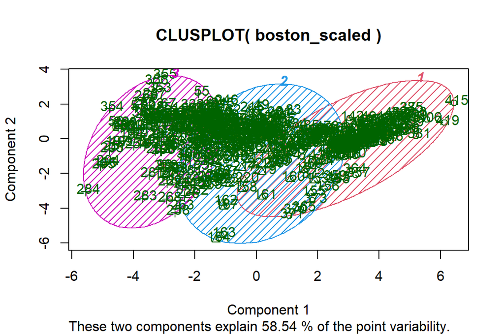

```r
library(cluster)
clusplot(boston_scaled, km$cluster, color=TRUE, shade=TRUE, labels=2, lines=0)
```

```r
####### here with 2 centers

km2 <-kmeans(boston_scaled, centers = 2) # k-means clustering

pairs(boston_scaled, col = km2$cluster) # plot of the Boston dataset with clusters
```

[output not shown]

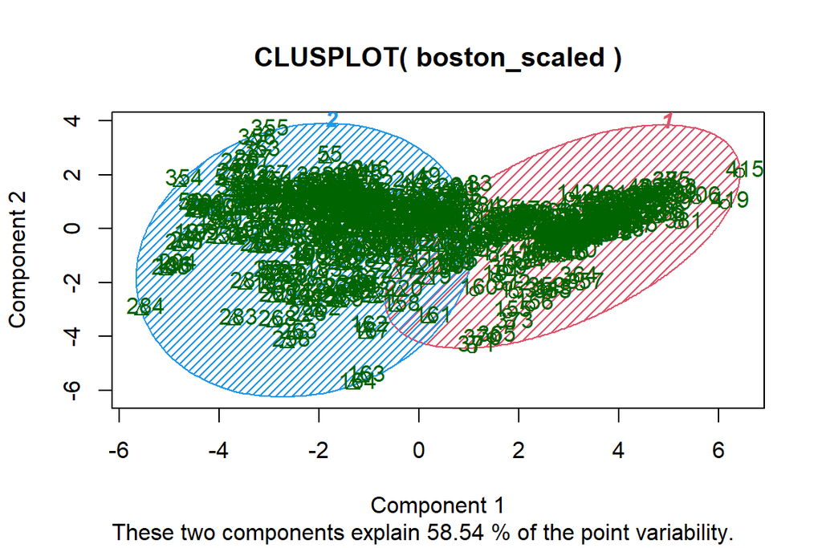

```r
library(cluster)
clusplot(boston_scaled, km2$cluster, color=TRUE, shade=TRUE, labels=2, lines=0)
```

```r
####

k_max8 <- 8 #  the number of clusters 8

twcss8 <- sapply(1:k_max8, function(k){kmeans(boston_scaled, k)$tot.withinss}) # the total within sum of squares
twcss8
```

```
## [1] 7070.000 4576.681 3871.374 3493.677 3114.920 2787.255 2572.206 2360.609
```

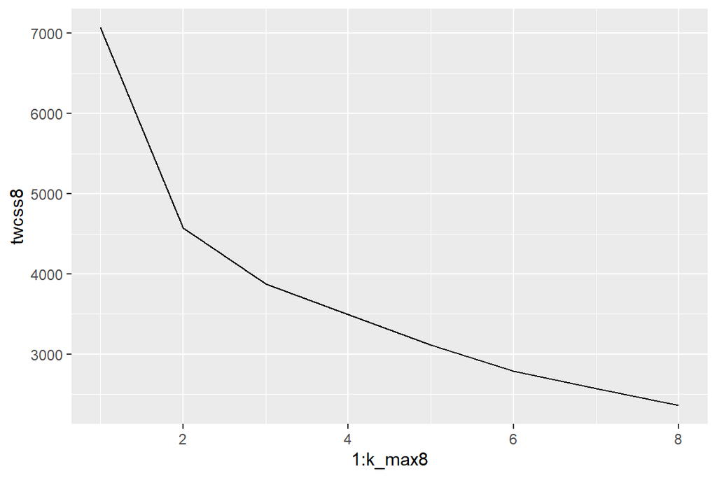

```r
qplot(x = 1:k_max8, y = twcss8, geom = 'line') # visualizing the results
```

```r
km <-kmeans(boston_scaled, centers = 2) # k-means clustering

pairs(boston_scaled, col = km$cluster) # plot of the Boston dataset with clusters
```

[output not shown]

```r
####

k_max3 <- 3 #  the number of clusters 3

twcss2 <- sapply(1:k_max3, function(k){kmeans(boston_scaled, k)$tot.withinss}) # the total within sum of squares
twcss2
```

```
## [1] 7070.000 4576.681 3884.598
```

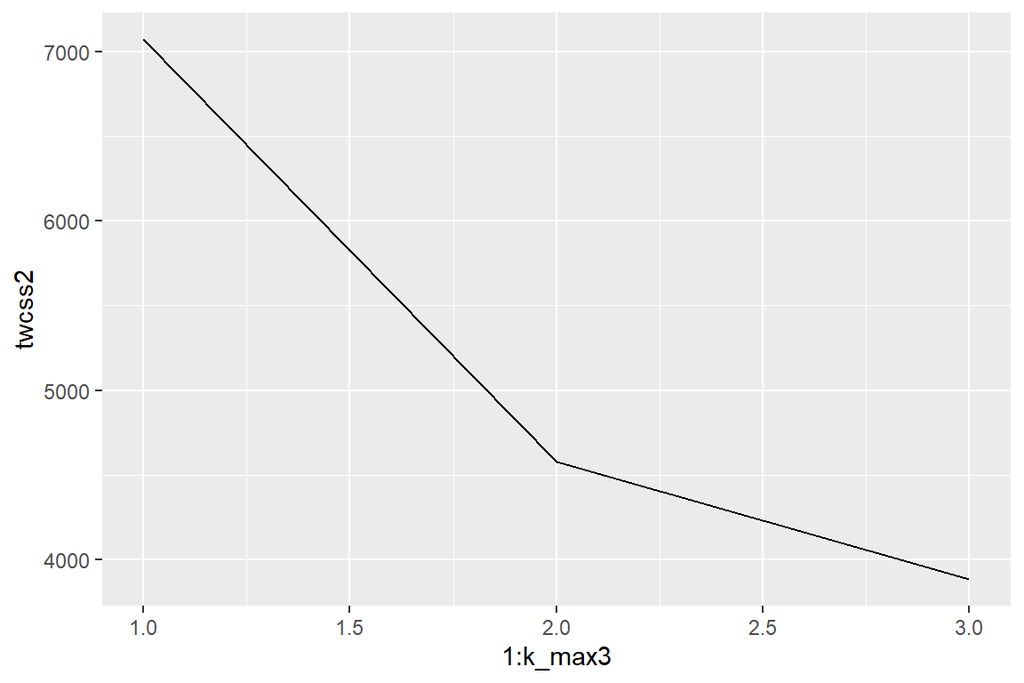

```r
qplot(x = 1:k_max3, y = twcss2, geom = 'line') # visualizing the results
```

```r
km <-kmeans(boston_scaled, centers = 2) # k-means clustering

pairs(boston_scaled, col = km$cluster) # plot of the Boston dataset with clusters
```

[output not shown]

```r
library(tidyverse)
library(ggplot2)
library(GGally)
library(corrplot)
library(factoextra)
#getwd()
```